# Loss Functions

### Introduction

Previously, we've gone through the basics in Part 1 of this demo series ([CF ensemble using ALS](https://colab.research.google.com/drive/1ePTzk_o1jfDRyzRKUlP7j308JDtXC81e?usp=sharing)). In this demo, we'll shift our focus toward experimental methods including the optimization using Tensorflow, designing neural architecture for CF ensemble learning, and cutomized loss functions.

### CFNet

- Key operations
  - Computing user and item embeddings
  - Taking dot product followed by a non-linear transformation (e.g. sigmoid)
- We'll also introduce `cf_models` module: A collection of NN-based models for CF ensemble and related utility functions

### Import Libraries

First, let's set up the enviornment and import related libraries ...

```python
# install openMP (as a prerequisite prior to installing faiss)
!sudo apt-get install libomp-dev
# => doing so allows for "pip install faiss"
# => which then also allows for "import utils_knn"

# NOTE:
# kNN-based methods won't be discussed until "Part 3" but we will have a bit of
# a spoiler alert here in order to use kNN to estimate labels in `T`
```

# install openMP (as a prerequisite prior to installing faiss) !sudo apt-get install libomp-dev # => doing so allows for "pip install faiss" # => which then also allows for "import utils_knn" # NOTE: # kNN-based methods won't be discussed until "Part 3" but we will have a bit of # a spoiler alert here in order to use kNN to estimate labels in `T`

[output not shown]

```python
import warnings
warnings.filterwarnings('ignore')

import numpy as np
import pandas as pd
from pandas import DataFrame, Series
import os, sys

# Colab
try:
  import google.colab
  IN_COLAB = True
except:
  IN_COLAB = False

# Plotting
import matplotlib.pylab as plt
# %matplotlib inline

from matplotlib.pyplot import figure
import seaborn as sns
from IPython.display import display

# Progress
from tqdm import tqdm

################################################################
# Configure system environment
# - Please modify input_dir according to your local enviornment
#
################################################################

cur_dir = os.getcwd()
project_dir = 'machine_learning_examples/cf_ensemble'
if IN_COLAB:
    # Run this demo on Google Colab
    from google.colab import drive
    drive.mount('/content/drive')

    # Parameters for data
    input_dir = f"/content/drive/MyDrive/Colab Notebooks/{project_dir}"
    # /content/drive/MyDrive/Colab Notebooks/machine_learning_examples/data/data-is-life

    sys.path.append(input_dir)
else:
    input_dir = cur_dir

if input_dir != cur_dir:
    sys.path.append(input_dir)
    print(f"> Adding {input_dir} to sys path ...")
    print(sys.path)
```

import warnings warnings.filterwarnings('ignore') import numpy as np import pandas as pd from pandas import DataFrame, Series import os, sys # Colab try: import google.colab IN_COLAB = True except: IN_COLAB = False # Plotting import matplotlib.pylab as plt # %matplotlib inline from matplotlib.pyplot import figure import seaborn as sns from IPython.display import display # Progress from tqdm import tqdm ################################################################ # Configure system environment # - Please modify input_dir according to your local enviornment # ################################################################ cur_dir = os.getcwd() project_dir = 'machine_learning_examples/cf_ensemble' if IN_COLAB: # Run this demo on Google Colab from google.colab import drive drive.mount('/content/drive') # Parameters for data input_dir = f"/content/drive/MyDrive/Colab Notebooks/{project_dir}" # /content/drive/MyDrive/Colab Notebooks/machine_learning_examples/data/data-is-life sys.path.append(input_dir) else: input_dir = cur_dir if input_dir != cur_dir: sys.path.append(input_dir) print(f"> Adding {input_dir} to sys path ...") print(sys.path)

```
> Adding /content/drive/MyDrive/Colab Notebooks/machine_learning_examples/cf_ensemble to sys path ...
['', '/content', '/env/python', '/usr/lib/python37.zip', '/usr/lib/python3.7', '/usr/lib/python3.7/lib-dynload', '/usr/local/lib/python3.7/dist-packages', '/usr/lib/python3/dist-packages', '/usr/local/lib/python3.7/dist-packages/IPython/extensions', '/root/.ipython', '/content/drive/MyDrive/Colab No…
```

```python
# Tensorflow
import tensorflow as tf
print(tf.__version__)
# import tensorflow_probability as tfp
# tfd = tfp.distributions
from tensorflow import keras

# from tensorflow.keras import layers
from tensorflow.keras.models import Model
from tensorflow.keras.layers import Input, Flatten, Dense, Dropout, Lambda, Embedding
from tensorflow.keras.optimizers import RMSprop
from keras.utils.vis_utils import plot_model
from tensorflow.keras import backend as K
#################################################################

# Scikit-learn
from sklearn.model_selection import train_test_split
from sklearn.model_selection import KFold, cross_val_predict, cross_val_score
from sklearn.model_selection import RepeatedStratifiedKFold
from sklearn.linear_model import LogisticRegression
from sklearn.neural_network import MLPClassifier
from sklearn.neighbors import KNeighborsClassifier
from sklearn.svm import SVC
from sklearn.gaussian_process import GaussianProcessClassifier
from sklearn.gaussian_process.kernels import RBF
from sklearn.tree import DecisionTreeClassifier
from sklearn.ensemble import RandomForestClassifier, AdaBoostClassifier, StackingClassifier
from sklearn.naive_bayes import GaussianNB
from sklearn.discriminant_analysis import QuadraticDiscriminantAnalysis
#################################################################

# CF-ensemble-specific libraries
import utils_stacking as ustk
import utils_classifier as uclf
import utils_sys as us
import utils_cf as uc
import scipy.sparse as sparse
from utils_sys import highlight
#################################################################

# try:
#     import faiss
# except:
#     # pip install faiss
#     usys.install('faiss')
#     import faiss

# Misc
import pprint
import tempfile
from typing import Dict, Text

np.set_printoptions(precision=3, edgeitems=5, suppress=True)
```

# Tensorflow import tensorflow as tf print(tf.__version__) # import tensorflow_probability as tfp # tfd = tfp.distributions from tensorflow import keras # from tensorflow.keras import layers from tensorflow.keras.models import Model from tensorflow.keras.layers import Input, Flatten, Dense, Dropout, Lambda, Embedding from tensorflow.keras.optimizers import RMSprop from keras.utils.vis_utils import plot_model from tensorflow.keras import backend as K ################################################################# # Scikit-learn from sklearn.model_selection import train_test_split from sklearn.model_selection import KFold, cross_val_predict, cross_val_score from sklearn.model_selection import RepeatedStratifiedKFold from sklearn.linear_model import LogisticRegression from sklearn.neural_network import MLPClassifier from sklearn.neighbors import KNeighborsClassifier from sklearn.svm import SVC from sklearn.gaussian_process import GaussianProcessClassifier from sklearn.gaussian_process.kernels import RBF from sklearn.tree import DecisionTreeClassifier from sklearn.ensemble import RandomForestClassifier, AdaBoostClassifier, StackingClassifier from sklearn.naive_bayes import GaussianNB from sklearn.discriminant_analysis import QuadraticDiscriminantAnalysis ################################################################# # CF-ensemble-specific libraries import utils_stacking as ustk import utils_classifier as uclf import utils_sys as us import utils_cf as uc import scipy.sparse as sparse from utils_sys import highlight ################################################################# # try: # import faiss # except: # # pip install faiss # usys.install('faiss') # import faiss # Misc import pprint import tempfile from typing import Dict, Text np.set_printoptions(precision=3, edgeitems=5, suppress=True)

```
2.8.0
```

### Generate some data to play with

```python
%matplotlib inline
from sklearn import datasets
from sklearn.datasets import make_classification
from collections import Counter

# get the dataset
c_ratio = 0.99

def get_dataset(n_samples=5000, noise=True):
    if noise:
        X,y = make_classification(n_samples=n_samples, n_features=100, n_informative=30,
                        n_redundant=6, n_repeated=3, n_classes=2, n_clusters_per_class=1,
                            class_sep=2,
                            flip_y=0.2, # <<<
                            weights=[c_ratio, ], random_state=17)
    else:
        X,y = make_classification(n_samples=n_samples, n_features=100, n_informative=30,
                            n_redundant=6, n_repeated=3, n_classes=2, n_clusters_per_class=1,
                                class_sep=2,
                                flip_y=0, weights=[c_ratio, ], random_state=17)
    return X, y

X, y =  get_dataset(noise=True)

# Plot data
f, ax1 = plt.subplots(nrows=1, ncols=1,figsize=(20,8))
sns.scatterplot(X[:,0],X[:,1],hue=y,ax=ax1);
ax1.set_title("With Noise");
plt.show();

uniq_labels = np.unique(y)
n_classes = len(uniq_labels)

# Turn into a binary classification problem
if n_classes > 2:
    print('> y before:\n', y)
    y, y_map, le = uclf.to_binary_classification(y, target_class=2)
    print('> y after:\n', y)

print(f'> n_classes: {n_classes}\n{uniq_labels}\n')

counter = Counter(y)
print(f'> counts:\n{counter}\n')
```

%matplotlib inline from sklearn import datasets from sklearn.datasets import make_classification from collections import Counter # get the dataset c_ratio = 0.99 def get_dataset(n_samples=5000, noise=True): if noise: X,y = make_classification(n_samples=n_samples, n_features=100, n_informative=30, n_redundant=6, n_repeated=3, n_classes=2, n_clusters_per_class=1, class_sep=2, flip_y=0.2, # <<< weights=[c_ratio, ], random_state=17) else: X,y = make_classification(n_samples=n_samples, n_features=100, n_informative=30, n_redundant=6, n_repeated=3, n_classes=2, n_clusters_per_class=1, class_sep=2, flip_y=0, weights=[c_ratio, ], random_state=17) return X, y X, y = get_dataset(noise=True) # Plot data f, ax1 = plt.subplots(nrows=1, ncols=1,figsize=(20,8)) sns.scatterplot(X[:,0],X[:,1],hue=y,ax=ax1); ax1.set_title("With Noise"); plt.show(); uniq_labels = np.unique(y) n_classes = len(uniq_labels) # Turn into a binary classification problem if n_classes > 2: print('> y before:\n', y) y, y_map, le = uclf.to_binary_classification(y, target_class=2) print('> y after:\n', y) print(f'> n_classes: {n_classes}\n{uniq_labels}\n') counter = Counter(y) print(f'> counts:\n{counter}\n')

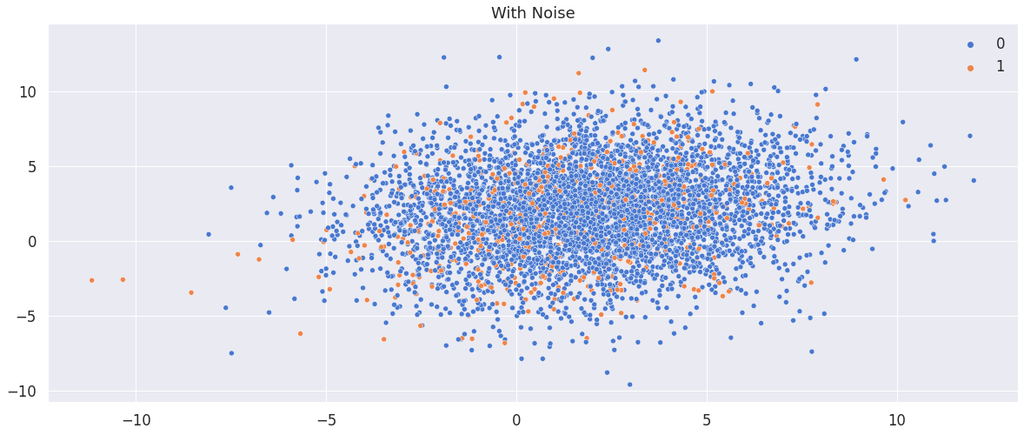

```
> n_classes: 2
[0 1]

> counts:
Counter({0: 4465, 1: 535})
```

### Setting up the CF ensemble learner

```python
# Create Base Learners
base_learners = [
                 ('RF', RandomForestClassifier(n_estimators= 200,
                                                   oob_score = True,
                                                   class_weight = "balanced",
                                                   random_state = 20,
                                                   ccp_alpha = 0.1)),
                 ('KNNC', KNeighborsClassifier(n_neighbors = len(np.unique(y))
                                                     , weights = 'distance')),
                #  ('SVC', SVC(kernel = 'linear', probability=True,
                #                    class_weight = 'balanced'
                #                   , break_ties = True)),

                 ('GNB', GaussianNB()),
                 ('QDA',  QuadraticDiscriminantAnalysis()),
                 ('MLPClassifier', MLPClassifier(alpha=1, max_iter=1000)),
                 # ('DT', DecisionTreeClassifier(max_depth=5)),
                 # ('GPC', GaussianProcessClassifier(1.0 * RBF(1.0))),
                ]
```

# Create Base Learners base_learners = [ ('RF', RandomForestClassifier(n_estimators= 200, oob_score = True, class_weight = "balanced", random_state = 20, ccp_alpha = 0.1)), ('KNNC', KNeighborsClassifier(n_neighbors = len(np.unique(y)) , weights = 'distance')), # ('SVC', SVC(kernel = 'linear', probability=True, # class_weight = 'balanced' # , break_ties = True)), ('GNB', GaussianNB()), ('QDA', QuadraticDiscriminantAnalysis()), ('MLPClassifier', MLPClassifier(alpha=1, max_iter=1000)), # ('DT', DecisionTreeClassifier(max_depth=5)), # ('GPC', GaussianProcessClassifier(1.0 * RBF(1.0))), ]

### Run CF Stacker

```python
from sklearn.metrics import f1_score

n_iter = 1

cf_stackers = []
for i in range(n_iter):
    # Initialize CF Stacker
    print(f"[info] Instantiate CFStacker #[{i+1}] ...")
    clf = ustk.CFStacker(estimators=base_learners,
                            final_estimator=LogisticRegression(),
                            work_dir = input_dir,
                            fold_number = i, # use this to index traing and test data
                            verbose=1)

    X_train, X_test, y_train, y_test = train_test_split(X, y, stratify=y, random_state=42)
    clf.fit(X_train, y_train)

    X_meta_test = clf.transform(X_test)
    print(f"[info] shape(X_meta_test): {X_meta_test.shape}")

    y_pred = clf.predict(X_test)
    perf_score = f1_score(y_test, y_pred)  # clf.score(X_test, y_test)
    print('[result]', perf_score)

    # Add test label for the convenience of future evaluation after applying a CF ensemble method
    clf.cf_write(dtype='test', y=y_test)

    # keep track of all the stackers (trained on differet parts of the same data as in CV or resampling)
    cf_stackers.append(clf)
```

from sklearn.metrics import f1_score n_iter = 1 cf_stackers = [] for i in range(n_iter): # Initialize CF Stacker print(f"[info] Instantiate CFStacker #[{i+1}] ...") clf = ustk.CFStacker(estimators=base_learners, final_estimator=LogisticRegression(), work_dir = input_dir, fold_number = i, # use this to index traing and test data verbose=1) X_train, X_test, y_train, y_test = train_test_split(X, y, stratify=y, random_state=42) clf.fit(X_train, y_train) X_meta_test = clf.transform(X_test) print(f"[info] shape(X_meta_test): {X_meta_test.shape}") y_pred = clf.predict(X_test) perf_score = f1_score(y_test, y_pred) # clf.score(X_test, y_test) print('[result]', perf_score) # Add test label for the convenience of future evaluation after applying a CF ensemble method clf.cf_write(dtype='test', y=y_test) # keep track of all the stackers (trained on differet parts of the same data as in CV or resampling) cf_stackers.append(clf)

```
[info] Instantiate CFStacker #[1] ...
(BaseCF) base est | name: RF, estimator: RandomForestClassifier(ccp_alpha=0.1, class_weight='balanced', n_estimators=200,
                       oob_score=True, random_state=20)
(BaseCF) base est | name: KNNC, estimator: KNeighborsClassifier(n_neighbors=2, weights='distance')
(BaseCF) base est | name: GNB, estimator: GaussianNB()
(BaseCF) base est | name: QDA, estimator: QuadraticDiscriminantAnalysis()
(BaseCF) base est | name: MLPClassifier, estimator: MLPClassifier(alpha=1, max_iter=1000)
(BaseCF) Base predictors:
[1]  RF: RandomForestClassifier(ccp_alpha=0.1, class_weight='balanced', n_estimators=200,
                       oob_score=True, random_state=20)
[2]  QDA: QuadraticDiscriminantAnalysis()
[3]  MLPClassifier: MLPClassifier(alpha=1, max_iter=1000)
[4]  KNNC: KNeighborsClassifier(n_neighbors=2, weights='distance')
[5]  GNB: GaussianNB()
```

```
[Parallel(n_jobs=1)]: Using backend SequentialBackend with 1 concurrent workers.
[Parallel(n_jobs=1)]: Done   5 out of   5 | elapsed:   28.3s finished
[Parallel(n_jobs=1)]: Using backend SequentialBackend with 1 concurrent workers.
[Parallel(n_jobs=1)]: Done   5 out of   5 | elapsed:    0.3s finished
[Parallel(n_jobs=1)]: Using backend SequentialBackend with 1 concurrent workers.
[Parallel(n_jobs=1)]: Done   5 out of   5 | elapsed:    0.0s finished
[Parallel(n_jobs=1)]: Using backend SequentialBackend with 1 concurrent workers.
[Parallel(n_jobs=1)]: Done   5 out of   5 | elapsed:    0.2s finished
[Parallel(n_jobs=1)]: Using backend SequentialBackend with 1 concurrent workers.
[Parallel(n_jobs=1)]: Done   5 out of   5 | elapsed:   29.7s finished
```

```
[info] Saving X_meta (shape=(3750, 5)) at:
/content/drive/MyDrive/Colab Notebooks/machine_learning_examples/cf_ensemble/data/train-0.npz

[info] Saving X_meta (shape=(1250, 5)) at:
/content/drive/MyDrive/Colab Notebooks/machine_learning_examples/cf_ensemble/data/test-0.npz

[info] shape(X_meta_test): (1250, 5)
[info] Saving X_meta (shape=(1250, 5)) at:
/content/drive/MyDrive/Colab Notebooks/machine_learning_examples/cf_ensemble/data/test-0.npz

[result] 0.0851063829787234
(cf_write) Adding new attribute y:
[0 0 0 0 0 ... 0 1 0 0 0]
...
(cf_write) Saving X_meta at:
/content/drive/MyDrive/Colab Notebooks/machine_learning_examples/cf_ensemble/data/test-0.npz
```

To speed things up, we could assume that the previous cell was executed at least once so that the necessary level-1 dataset has been generated (probabilty matrix from base classifiers, etc.).

- Uncomment below if you wish to bypass the base predictor training step above

```python
# fold_number = 0

# # Instantiate a new CFStacker if you do not wish to spend time training base classifiers above
# # ... this is ok assuming that pre-trained level-1 datasets are available under ./data
# print("[info] Instantiating a new instance of CFStacker bypassing training loop (assuming pre-trained data available) ...")
# clf = ustk.CFStacker(estimators=base_learners,
#                     final_estimator=LogisticRegression(), # <<< this is to be changed into a CF ensemble method
#                     work_dir = input_dir,
#                     fold_number = fold_number, # Use this to index traing and test data
#                     verbose=1)

# Or simply use the static method without even creating an instance of CFStacker
# ustk.CFStacker.cf_fetch2(fold_number=fold_number)
```

# fold_number = 0 # # Instantiate a new CFStacker if you do not wish to spend time training base classifiers above # # ... this is ok assuming that pre-trained level-1 datasets are available under ./data # print("[info] Instantiating a new instance of CFStacker bypassing training loop (assuming pre-trained data available) ...") # clf = ustk.CFStacker(estimators=base_learners, # final_estimator=LogisticRegression(), # <<< this is to be changed into a CF ensemble method # work_dir = input_dir, # fold_number = fold_number, # Use this to index traing and test data # verbose=1) # Or simply use the static method without even creating an instance of CFStacker # ustk.CFStacker.cf_fetch2(fold_number=fold_number)

```python
import data_pipeline as dp
import polarity_models as pmodel

# Load pre-trained level-1 data (associated with a given fold number)
fold_number = 0
R, T, U, L_train, L_test = dp.load_pretrained_level1_data(clf=clf, fold_number=fold_number, verbose=1)
n_train = R.shape[1]

# Estimate probability thresholds according to `fmax`
policy_threshold = 'balanced'
p_threshold = uc.estimateProbThresholds(R, L=L_train, pos_label=1, policy=policy_threshold)

# Remember to use "estimated labels" for the test set; not the true label `L_test` that we are trying to predict

# Method #1: Majority vote
lh = uc.estimateLabels(T, p_th=p_threshold) # We cannot use L_test (cheating), but we have to guesstimate

# Method #2: kNN
# Pc, Lh = pmodel.color_matrix(R, L_train, p_threshold)
# lh = uc.estimateLabelsByRanking(R, T, L_train, Pc, topn=3) # NOTE: tricky to make faiss library work here

L = np.hstack((L_train, lh))
X = np.hstack((R, T))

assert len(U) == X.shape[0]
print(f"> shape(R):{R.shape} || shape(T): {T.shape} => shape(X): {X.shape}")
```

import data_pipeline as dp import polarity_models as pmodel # Load pre-trained level-1 data (associated with a given fold number) fold_number = 0 R, T, U, L_train, L_test = dp.load_pretrained_level1_data(clf=clf, fold_number=fold_number, verbose=1) n_train = R.shape[1] # Estimate probability thresholds according to `fmax` policy_threshold = 'balanced' p_threshold = uc.estimateProbThresholds(R, L=L_train, pos_label=1, policy=policy_threshold) # Remember to use "estimated labels" for the test set; not the true label `L_test` that we are trying to predict # Method #1: Majority vote lh = uc.estimateLabels(T, p_th=p_threshold) # We cannot use L_test (cheating), but we have to guesstimate # Method #2: kNN # Pc, Lh = pmodel.color_matrix(R, L_train, p_threshold) # lh = uc.estimateLabelsByRanking(R, T, L_train, Pc, topn=3) # NOTE: tricky to make faiss library work here L = np.hstack((L_train, lh)) X = np.hstack((R, T)) assert len(U) == X.shape[0] print(f"> shape(R):{R.shape} || shape(T): {T.shape} => shape(X): {X.shape}")

```
[info] list of base classifiers:
['RF' 'KNNC' 'GNB' 'QDA' 'MLPClassifier']

(estimateProbThresholds) policy: fmax
[info] probability thresholds:
[0.499 0.    0.008 0.    0.007]

> shape(R):(5, 3750) || shape(T): (5, 1250) => shape(X): (5, 5000)
```

#### At this point, we have all the key matrices ready. They are:

- `R`: Probability/rating matrix for the training split, in which `R[i][j]` is the conditional probability output (i.e. P(y=1|X)) for the i-th base classifier ("user") predicting j-th training instance ("item").
- `T`: Probability/rating matrix for the test split.
- `X`: A column-stacked matrix combining `R` and `T` into a single matrix.
- `U`: Names of users/classifiers in the order consistent with `axis=0` or row order of the rating matrices like `X`
- `p_threshold`: Probability thresholds associated with the base classifiers. Each base classifier has its own threshold that optimizes a given performance matrix (E.g., the best probability threshold that reaches the best F1 score is called Fmax).
- `L_train`: True labels for the training splie
- `lh`: Estimated labels for the test split (we need this to establish the optimization that derives latent factors)
- `L_test`: True labels for the test split (what we aim to predict)

### Confidence Matrix

A mentioned in Part 1, a confidence matrix (C) is a matrix comprising confidence measures: `C[i][j]` is a confidence measure for i-th base classifier's prediction on j-th data point. Confidence matrix can come in a few different forms:

- `C0`: The (raw) confidence matrix whose rows and columns are consistent with those of the probabilty/rating matrix (`R`, `T` or `X`). `C0` holds the confidence scores prior to any masking and re-weighting operations.
- `Cw`: Re-weighted confidence matrix (without masking). See `utils_cf.balance_and_rescale()` for more details. `Cw` is a "dense" confidence matrix, meaning that no "masking" is applied; that is, confidence scores for TPs, TNs and even FPs, FNs are all preserved.
- `Cn`: Masked confidence matrix in which the confidence measures for a subset of the entries in `Cw` are "masked" (zero-ed out) such that they do not enter into the optimization objective for latent factors. Exactly which entries are masked (zero-ed) depends on the masking strategy. Typically, we mask entries associated with FPs and FNs. We may also wish to mask entries with high uncertainty degrees (E.g., probability values close to 0.5 or other probability threshold, for which the labeling is unclear).

#### Related

- `Pc`: Color matrix

```python
import polarity_models as pm
"""
Setting up confidence Matrix.

Key Parameters
--------------
X: probabilty/rating matrix, X=[R|T]
L: labels (including the guesstimated labels associated with T)

p_threshold:
policy_threshold:
  options: 'fmax', 'balanced', ...
  this determines how `p_threshold` is estimated

conf_measure: Measure of reliabliity (of probability scores)

alpha: The factor by which confidence scores in C0 is to be scaled
        in the latent-factor optimization objective
beta: The factor by which TP-specific confidence scores are amplified (
      so that these terms are penalized more severely in the cost function,
      if not approximated well)

"""
########################################################################
n_factors = 100
alpha = 100.0
beta = 1.0
conf_measure = 'brier' # 'brier', 'uniform', ...
policy_threshold = 'balanced'

Pc, C0, Cw, Cn, *rest = \
    uc.evalConfidenceMatrices(X, L, alpha=alpha,
                                    p_threshold=p_threshold,
                                    conf_measure=conf_measure, policy_threshold=policy_threshold,

                                    # Optional debug/test parameters
                                    U=U, fold_number=fold_number,
                                    # n_train = n_train,
                                    is_cascade=True,
                                    verbose=1)
y_colors = pm.verify_colors(Pc, X)
# Cn = uc.shift(Cn, -1.0)
############################################################
```

import polarity_models as pm """ Setting up confidence Matrix. Key Parameters -------------- X: probabilty/rating matrix, X=[R|T] L: labels (including the guesstimated labels associated with T) p_threshold: policy_threshold: options: 'fmax', 'balanced', ... this determines how `p_threshold` is estimated conf_measure: Measure of reliabliity (of probability scores) alpha: The factor by which confidence scores in C0 is to be scaled in the latent-factor optimization objective beta: The factor by which TP-specific confidence scores are amplified ( so that these terms are penalized more severely in the cost function, if not approximated well) """ ######################################################################## n_factors = 100 alpha = 100.0 beta = 1.0 conf_measure = 'brier' # 'brier', 'uniform', ... policy_threshold = 'balanced' Pc, C0, Cw, Cn, *rest = \ uc.evalConfidenceMatrices(X, L, alpha=alpha, p_threshold=p_threshold, conf_measure=conf_measure, policy_threshold=policy_threshold, # Optional debug/test parameters U=U, fold_number=fold_number, # n_train = n_train, is_cascade=True, verbose=1) y_colors = pm.verify_colors(Pc, X) # Cn = uc.shift(Cn, -1.0) ############################################################

```
================================================================================
(evalConfidenceMatrix) policy_filtering: item, policy_opt: rating | conf_measure: brier | policy_threshold: balanced, ratio_users: 0.5, ratio_small_class: 0, supervised? True, mask_all_test? False
================================================================================


... Filtering policy in training split: item =?= test split: polarity
################################################################################
(evalConfidenceMatrix) labeling_model: simple | constrained? True, stochastic? True, est sample type? False
################################################################################
... Balance class | balance sample size distribution? False, balance class conf scores? False
... Posthoc weight adjustments? | beta: 1.0, suppress_negative_examples: False
================================================================================
(toConfidenceMatrix) List of proba thresholds given policy: balanced | sorted according to -- classifer --
================================================================================
... [1] GNB: p_th = 0.234137
... [2] KNNC: p_th = 0.492823
... [3] MLPClassifier: p_th = 0.241718
... [4] QDA: p_th = 0.000486
... [5] RF: p_th = 0.500503
(toConfidenceMatrix) Computing conficence scores using conf_measure: brier
...                   p_threshold? True | message passing? False | policy: balanced
(confidence2D) item/data-wise confidence score distributions ...
... data [1879] | [0.2 0.8 0.8 0.8 0.4]
... data [711] | [0.2 0.8 0.8 0.8 0.4]
... data [3243] | [0.2 0.8 0.8 0.8 0.4]
... data [3651] | [0.2 0.8 0.8 0.8 0.4]
... data [3852] | [0.2 0.8 0.8 0.8 0.4]
(confidence2D) confidence weights (mode=brier)
... Wu:
[0.75  0.884 0.91  0.8   0.904]

... Wi:
[0.2 0.8 0.8 0.8 0.4 0.8 0.8 0.4 0.4 0.6]

... W:
[[0.15  0.6   0.6   0.6   0.3   0.6   0.6   0.3   0.3   0.45 ]
 [0.177 0.707 0.707 0.707 0.354 0.707 0.707 0.354 0.354 0.53 ]
 [0.182 0.728 0.728 0.728 0.364 0.728 0.728 0.364 0.364 0.546]
 [0.16  0.64  0.64  0.64  0.32  0.64  0.64  0.32  0.32  0.48 ]
 [0.181 0.723 0.723 0.723 0.362 0.723 0.723 0.362 0.362 0.543]]
```

[output cut: 788 more lines]

```

[verify] [TP] BP=[MLPClassifier]: n(P): 450, n(TP): 104, recall: 0.2311111111111111

[32.395 43.193 43.193 43.193 43.193 43.193 43.193 32.395 43.193 43.193]
... Min: 10.798287251357841, max: 53.99143625678919, median: 32.39486175407352
... condition: ((after) balanced + magnified (alpha=100.0, beta=1.0) | dtype: training set)

[verify] [TN] BP=[MLPClassifier]: n(N): 4550, n(TN): 4106, TNR: 0.9024175824175824

[2.094 1.675 2.094 1.675 1.675 2.094 2.094 1.256 1.256 1.675]
... Min: 0.41871028928795473, max: 2.0935514464397733, median: 1.674841157151819
... condition: ((after) balanced + magnified (alpha=100.0, beta=1.0) | dtype: training set)


[info] class stats: {'n_pos': 450, 'n_neg': 4550, 'n_min_class': 450, 'n_max_class': 4550, 'n': 5000, 'r_pos': 0.09, 1: 0.09, 'r_neg': 0.91, 0: 0.91, 'r_min': 0.09, 'r_minority': 0.09, 'r_max': 0.91, 'r_majority': 0.91, 'min_class': 1, 'minority_class': 1, 'max_class': 0, 'majority_class': 0, 'r_max…
```

```python
from numpy import linalg as LA
from scipy.spatial import distance
from sklearn.metrics import f1_score
from analyzer import analyze_matrix_type
import utils_cf as uc
import cf

fold_number = 0

# Uncomment the following if starting the notebook from here (bypassing training and optimization)
###############################################################################
# ret = ustk.get_pretrained_model_with_confidence_matrix(input_dir,
#                                                        base_learners,
#                                                        fold_number,
#                                                        policy_threshold='balanced',
#                                                        conf_measure='brier',
#                                                        verbose=1)
# X, L, U, p_threshold, n_train = ret['X'], ret['L'], ret['U'], ret['p_threshold'], ret['n_train']
# R, T = X[:,:n_train], X[:,n_train:]
# Cn, Pc = ret['Cn'], ret['Pc']
###############################################################################
ustk.verify_shape(X, R, T, L, U, p_threshold) # verify the shape of all key quantities

# Check: Wherever Pc is negative, the corresponding entries in Cn must be 0 (By constrast, C is a full/dense confidence matrix)
assert np.all(Cn[Pc < 0]==0)
assert np.all(Cn[Pc > 0]>0)
```

from numpy import linalg as LA from scipy.spatial import distance from sklearn.metrics import f1_score from analyzer import analyze_matrix_type import utils_cf as uc import cf fold_number = 0 # Uncomment the following if starting the notebook from here (bypassing training and optimization) ############################################################################### # ret = ustk.get_pretrained_model_with_confidence_matrix(input_dir, # base_learners, # fold_number, # policy_threshold='balanced', # conf_measure='brier', # verbose=1) # X, L, U, p_threshold, n_train = ret['X'], ret['L'], ret['U'], ret['p_threshold'], ret['n_train'] # R, T = X[:,:n_train], X[:,n_train:] # Cn, Pc = ret['Cn'], ret['Pc'] ############################################################################### ustk.verify_shape(X, R, T, L, U, p_threshold) # verify the shape of all key quantities # Check: Wherever Pc is negative, the corresponding entries in Cn must be 0 (By constrast, C is a full/dense confidence matrix) assert np.all(Cn[Pc < 0]==0) assert np.all(Cn[Pc > 0]>0)

Sanity check on the particle types ...

```python
import collections
from analyzer import is_sparse

print(f"> Is Pc sparse? {is_sparse(Pc)}")
print(f"> Is Cn sparse? {is_sparse(Cn)}")

print(np.unique(Pc.A if is_sparse(Pc) else Pc))
assert (X.shape == C0.shape ) and (Pc.shape == Cn.shape)

counter = collections.Counter((Pc.A if is_sparse(Pc) else Pc).reshape(-1, ))
print(counter)
```

import collections from analyzer import is_sparse print(f"> Is Pc sparse? {is_sparse(Pc)}") print(f"> Is Cn sparse? {is_sparse(Cn)}") print(np.unique(Pc.A if is_sparse(Pc) else Pc)) assert (X.shape == C0.shape ) and (Pc.shape == Cn.shape) counter = collections.Counter((Pc.A if is_sparse(Pc) else Pc).reshape(-1, )) print(counter)

```
> Is Pc sparse? True
> Is Cn sparse? True
[-2. -1.  1.  2.]
Counter({1.0: 18491, -2.0: 4259, -1.0: 1533, 2.0: 717})
```

### Experiment #1: CFNet using MSE loss

### 1A. Preparing training data for CFNet using MSE loss

- We'll begin by experimenting on simple, frequently-used loss functions:
  - If we intend to approximate probability scores in X, then MSE would be a reasonable loss function to try. Specifically, we want use the latent factors to approximate the probabilities in X. CFNet essentially learns a function *f(x, y)* that approximates the probability score associated with user *x* and item *y*.
  - If we intend to approximate the labeling entailed by X (given base predictor's probability thresholds, `p_threshold`), then BCE loss would be a reasonable choice.
- In this first experiment, we will use latent factors to approximate probability scores in `X` directly

```python
import data_pipeline as dp
# from utils_cf import estimateLabelMatrix, estimateLabels

df = dp.rating_matrix_to_dataframe(X, shuffle=True)
n_users0, n_items0 = X.shape

# [test]
#########################################
assert df.shape[0] == X.size
# df.astype({'user': 'int32', 'item': 'int64'})
for i, dfi in df.iterrows():
    if i > 100: break
    r, c, score = dfi['user'], dfi['item'], dfi['rating']
    assert np.allclose(X[r][c], score)
#########################################

C = Cn # use the masked and rescaled confidence matrix
P = uc.to_preference(Pc) # color matrix to probability filter (where {TP, TN} maps to 1 and {FP, FN} maps to 0)
Xc, yc, weights, proba_filter = dp.matrix_to_augmented_training_data(X, C, P) # NOTE: Don't overwrite X (`Xc` is not the same as `X`, which is a rating matrix)

# Sample weights
##########################################
# Without amplifying TP's weights (TP and TN are equally important)
# sample_weights = weights * proba_filter

# Amplifying TP weights inversely proportioinal to the TP sample size relative to TN
# E.g. If sample size of TP is 1/10th that of TN, then TP's weight should be 10-fold larger
sample_weights = dp.unravel(C, normalize=False) # Cn is a masked and balanced version of C0
assert len(sample_weights) == Xc.shape[0]
##########################################

test_size = 0.1

# Make train-test split with sample weights
split_pt = int((1-test_size) * Xc.shape[0])

X_train, X_val, y_train, y_val, W_train, W_val = (
    Xc[:split_pt],
    Xc[split_pt:],
    yc[:split_pt],
    yc[split_pt:],
    sample_weights[:split_pt],
    sample_weights[split_pt:]
)

# A few other ways of making train-test splits

# Create a training dataset that includes sample weights
# train_dataset = tf.data.Dataset.from_tensor_slices((Xc, yc, sample_weights))

# splits = dp.get_dataset_partitions_tf(train_dataset, Xc.shape[0],
#                              train_split=0.8, val_split=0.0, test_split=0.2,
#                              shuffle=True, shuffle_size=10000, random_state=53)
# train_dataset, _, test_dataset = splits

# X_train, X_val, y_train, y_val = train_test_split(Xc, yc, test_size=test_size, random_state=53)

# Test
print(f"> shape(X_train): {X_train.shape}, shape(X_val): {X_val.shape}")
assert X.size == X_train.shape[0] + X_val.shape[0]
```

import data_pipeline as dp # from utils_cf import estimateLabelMatrix, estimateLabels df = dp.rating_matrix_to_dataframe(X, shuffle=True) n_users0, n_items0 = X.shape # [test] ######################################### assert df.shape[0] == X.size # df.astype({'user': 'int32', 'item': 'int64'}) for i, dfi in df.iterrows(): if i > 100: break r, c, score = dfi['user'], dfi['item'], dfi['rating'] assert np.allclose(X[r][c], score) ######################################### C = Cn # use the masked and rescaled confidence matrix P = uc.to_preference(Pc) # color matrix to probability filter (where {TP, TN} maps to 1 and {FP, FN} maps to 0) Xc, yc, weights, proba_filter = dp.matrix_to_augmented_training_data(X, C, P) # NOTE: Don't overwrite X (`Xc` is not the same as `X`, which is a rating matrix) # Sample weights ########################################## # Without amplifying TP's weights (TP and TN are equally important) # sample_weights = weights * proba_filter # Amplifying TP weights inversely proportioinal to the TP sample size relative to TN # E.g. If sample size of TP is 1/10th that of TN, then TP's weight should be 10-fold larger sample_weights = dp.unravel(C, normalize=False) # Cn is a masked and balanced version of C0 assert len(sample_weights) == Xc.shape[0] ########################################## test_size = 0.1 # Make train-test split with sample weights split_pt = int((1-test_size) * Xc.shape[0]) X_train, X_val, y_train, y_val, W_train, W_val = ( Xc[:split_pt], Xc[split_pt:], yc[:split_pt], yc[split_pt:], sample_weights[:split_pt], sample_weights[split_pt:] ) # A few other ways of making train-test splits # Create a training dataset that includes sample weights # train_dataset = tf.data.Dataset.from_tensor_slices((Xc, yc, sample_weights)) # splits = dp.get_dataset_partitions_tf(train_dataset, Xc.shape[0], # train_split=0.8, val_split=0.0, test_split=0.2, # shuffle=True, shuffle_size=10000, random_state=53) # train_dataset, _, test_dataset = splits # X_train, X_val, y_train, y_val = train_test_split(Xc, yc, test_size=test_size, random_state=53) # Test print(f"> shape(X_train): {X_train.shape}, shape(X_val): {X_val.shape}") assert X.size == X_train.shape[0] + X_val.shape[0]

```
> shape(X_train): (22500, 2), shape(X_val): (2500, 2)
```

### More complex loss functions

- We could further define a confidence-weighted loss fucntion that is also aware of the "color" as given by `confidence_weighted_loss(...)` below. However, this initial implementation won't work with TF's model.fit(). Why?
  - The model.fit() framework only accepts loss functions that take on (y_true, y_pred) as inputs; if we need to pass on additional parameters that also influence the loss calculation, we need to do additoinal work ...
  - `if-then-else` statements won't work and are not recommended.
  - We also need to ensure that boolean masks are converted to tf.float32 so that they can be used to establish the weighted loss
- Given the observations above, an example of the confidence weighted_loss is implemented in `cf_models` module, which will be introduced shortly.

```python
# y_pred: f( <x, y> ) # <x, y> denotes the dot product between x and y

def confidence_weighted_loss(y_true, y_pred, weights=None, colors=None): # this has to be used with .add_loss() with greater flexibility
    if weights is None:
        weights = K.ones_like(y_pred)

    if colors is None:
        # confidence-weighted sum of squares
        wmse = weights * K.square(y_pred - y_true, axis=-1) # difference between predicted and "true" probability
    else:
        # condition
        mask_tp = K.equal(colors, 2)
        mask_tn = K.equal(colors, 1)
        mask_fp = K.equal(colors, -2)
        mask_fn = K.equal(colors, -1)

        # if TP, want y_pred >= y_true, i.e. the larger (the closer to 1), the better
        loss_tp = weights * K.square(K.maximum(y_true-y_pred, 0)) # if y_pred > y_true => y_true-y_pred < 0 => no loss, if ow, then the smaller, the higher the penalty (quadratically)

        # if TN, want y_pred < y_true, i.e. the smaller (the closer to 0), the better
        loss_tn = weights * K.square(K.maximum(y_pred-y_true, 0)) # if y_true>y_pred => y_pred-y_true < 0 => no loss

        # if FP, y_pred must've been too large, want y_pred smaller
        loss_fp = loss_tn
        # loss_fp = weights * K.pow(K.maximum(y_true-y_pred, 0) # may need to be 'a lot' smaller => could penalize error cubically instead

        # if FN, y_pred must've been too small, want y_pred larger
        loss_fn = loss_tp
        # loss_fn = weights * K.pow(K.maximum(y_pred-y_true, 0), 3) # penalize cubically or any exponent > 2

        wmse = mask_tp * loss_tp + mask_tn * loss_tn + mask_fp * loss_fp + mask_fn * loss_fn
    return wmse
```

# y_pred: f( ) # denotes the dot product between x and y def confidence_weighted_loss(y_true, y_pred, weights=None, colors=None): # this has to be used with .add_loss() with greater flexibility if weights is None: weights = K.ones_like(y_pred) if colors is None: # confidence-weighted sum of squares wmse = weights * K.square(y_pred - y_true, axis=-1) # difference between predicted and "true" probability else: # condition mask_tp = K.equal(colors, 2) mask_tn = K.equal(colors, 1) mask_fp = K.equal(colors, -2) mask_fn = K.equal(colors, -1) # if TP, want y_pred >= y_true, i.e. the larger (the closer to 1), the better loss_tp = weights * K.square(K.maximum(y_true-y_pred, 0)) # if y_pred > y_true => y_true-y_pred < 0 => no loss, if ow, then the smaller, the higher the penalty (quadratically) # if TN, want y_pred < y_true, i.e. the smaller (the closer to 0), the better loss_tn = weights * K.square(K.maximum(y_pred-y_true, 0)) # if y_true>y_pred => y_pred-y_true < 0 => no loss # if FP, y_pred must've been too large, want y_pred smaller loss_fp = loss_tn # loss_fp = weights * K.pow(K.maximum(y_true-y_pred, 0) # may need to be 'a lot' smaller => could penalize error cubically instead # if FN, y_pred must've been too small, want y_pred larger loss_fn = loss_tp # loss_fn = weights * K.pow(K.maximum(y_pred-y_true, 0), 3) # penalize cubically or any exponent > 2 wmse = mask_tp * loss_tp + mask_tn * loss_tn + mask_fp * loss_fp + mask_fn * loss_fn return wmse

### 1B. Create the model

- See `cf_models` for a few example models

```python
class CFNet(keras.Model):
    def __init__(self, n_users, n_items, embedding_size, **kwargs):
        super(CFNet, self).__init__(**kwargs)
        self.n_users = n_users
        self.n_items = n_items
        self.embedding_size = embedding_size
        self.user_embedding = Embedding(
            n_users,
            embedding_size,
            embeddings_initializer="he_normal",
            embeddings_regularizer=keras.regularizers.l2(0.01),
        )
        self.user_bias = Embedding(n_users, 1)

        self.item_embedding = Embedding(
            n_items,
            embedding_size,
            embeddings_initializer="he_normal",
            embeddings_regularizer=keras.regularizers.l2(0.01),
        )
        self.item_bias = Embedding(n_items, 1)

    def call(self, inputs):
        user_vector = self.user_embedding(inputs[:, 0])
        user_bias = self.user_bias(inputs[:, 0])

        item_vector = self.item_embedding(inputs[:, 1])
        item_bias = self.item_bias(inputs[:, 1])

        dot_user_item = tf.tensordot(user_vector, item_vector, 2)
        # Add all the components (including bias)
        x = dot_user_item + user_bias + item_bias

        # The sigmoid activation forces the rating to between 0 and 1
        return tf.nn.sigmoid(x)
```

class CFNet(keras.Model): def __init__(self, n_users, n_items, embedding_size, **kwargs): super(CFNet, self).__init__(**kwargs) self.n_users = n_users self.n_items = n_items self.embedding_size = embedding_size self.user_embedding = Embedding( n_users, embedding_size, embeddings_initializer="he_normal", embeddings_regularizer=keras.regularizers.l2(0.01), ) self.user_bias = Embedding(n_users, 1) self.item_embedding = Embedding( n_items, embedding_size, embeddings_initializer="he_normal", embeddings_regularizer=keras.regularizers.l2(0.01), ) self.item_bias = Embedding(n_items, 1) def call(self, inputs): user_vector = self.user_embedding(inputs[:, 0]) user_bias = self.user_bias(inputs[:, 0]) item_vector = self.item_embedding(inputs[:, 1]) item_bias = self.item_bias(inputs[:, 1]) dot_user_item = tf.tensordot(user_vector, item_vector, 2) # Add all the components (including bias) x = dot_user_item + user_bias + item_bias # The sigmoid activation forces the rating to between 0 and 1 return tf.nn.sigmoid(x)

```python
n_users = len(np.unique(df['user']))
n_items = len(np.unique(df['item']))
assert n_users == n_users0 == X.shape[0], f"n_users: {n_users} != n(rows) in X: {X.shape[0]}"
assert n_items == n_items0 == X.shape[1], f"n_items: {n_items} != n(cols) in X: {X.shape[1]}"

print(f'[info] shape(X): {X.shape} => n_users={n_users}, n_items={n_items}')
```

n_users = len(np.unique(df['user'])) n_items = len(np.unique(df['item'])) assert n_users == n_users0 == X.shape[0], f"n_users: {n_users} != n(rows) in X: {X.shape[0]}" assert n_items == n_items0 == X.shape[1], f"n_items: {n_items} != n(cols) in X: {X.shape[1]}" print(f'[info] shape(X): {X.shape} => n_users={n_users}, n_items={n_items}')

```
[info] shape(X): (5, 5000) => n_users=5, n_items=5000
```

```python
n_factors = 100
epochs = 120
#######################################################
loss_fn = mse = tf.keras.losses.MeanSquaredError()

# Options:
#     bce = tf.keras.losses.BinaryCrossentropy() # Note: Use BCE loss if we are approximating labels (0s and 1s)
#     mse = tf.keras.losses.MeanSquaredError() # Note: Use MSE loss if we are approximating probability scores instead of labels
#######################################################

model = CFNet(n_users, n_items, n_factors)
model.compile(
    loss=loss_fn, optimizer=keras.optimizers.Adam(lr=0.001)
)
```

n_factors = 100 epochs = 120 ####################################################### loss_fn = mse = tf.keras.losses.MeanSquaredError() # Options: # bce = tf.keras.losses.BinaryCrossentropy() # Note: Use BCE loss if we are approximating labels (0s and 1s) # mse = tf.keras.losses.MeanSquaredError() # Note: Use MSE loss if we are approximating probability scores instead of labels ####################################################### model = CFNet(n_users, n_items, n_factors) model.compile( loss=loss_fn, optimizer=keras.optimizers.Adam(lr=0.001) )

### 1C. Train and evaluate the model

```python
# Use TensorBoard to visualize metrics including loss and accuracy.
tensorboard_callback = tf.keras.callbacks.TensorBoard(log_dir="logs")

history = model.fit(
    x=X_train,
    y=y_train,
    sample_weight=W_train,
    batch_size=64,
    epochs=epochs,
    verbose=1,
    validation_data=(X_val, y_val, W_val), # test how the model predict unseen ratings
    callbacks=[tensorboard_callback]
)
```

# Use TensorBoard to visualize metrics including loss and accuracy. tensorboard_callback = tf.keras.callbacks.TensorBoard(log_dir="logs") history = model.fit( x=X_train, y=y_train, sample_weight=W_train, batch_size=64, epochs=epochs, verbose=1, validation_data=(X_val, y_val, W_val), # test how the model predict unseen ratings callbacks=[tensorboard_callback] )

```python
model.summary()
```

model.summary()

```
Model: "cf_net"
_________________________________________________________________
 Layer (type)                Output Shape              Param #
=================================================================
 embedding (Embedding)       multiple                  500

 embedding_1 (Embedding)     multiple                  5

 embedding_2 (Embedding)     multiple                  500000

 embedding_3 (Embedding)     multiple                  5000

=================================================================
Total params: 505,505
Trainable params: 505,505
Non-trainable params: 0
_________________________________________________________________
```

```python
plot_model(model, show_shapes=True, show_layer_names=True, to_file='cf-model.png')
```

[output not shown]

plot_model(model, show_shapes=True, show_layer_names=True, to_file='cf-model.png')

```python
%matplotlib inline
f, ax1 = plt.subplots(nrows=1, ncols=1,figsize=(20,8))

plt.plot(history.history["loss"])
plt.plot(history.history["val_loss"])
plt.title("model loss")
plt.ylabel("loss")
plt.xlabel("epoch")
plt.legend(["train", "test"], loc="upper left")
plt.show()
```

%matplotlib inline f, ax1 = plt.subplots(nrows=1, ncols=1,figsize=(20,8)) plt.plot(history.history["loss"]) plt.plot(history.history["val_loss"]) plt.title("model loss") plt.ylabel("loss") plt.xlabel("epoch") plt.legend(["train", "test"], loc="upper left") plt.show()

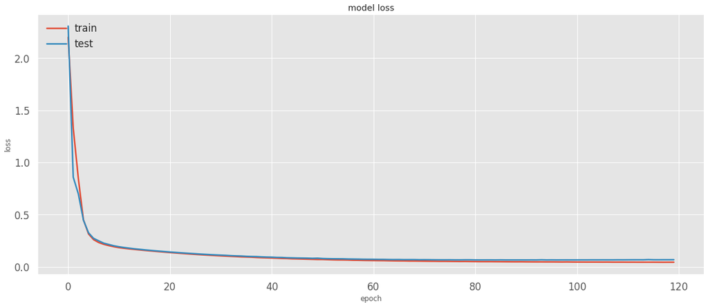

```python
%load_ext tensorboard
%tensorboard --logdir logs
```

%load_ext tensorboard %tensorboard --logdir logs

```
Output hidden; open in https://colab.research.google.com to view.
```

But we really care about in model stacking is to predict the test set (`T`) ...

```python
from utils_sys import highlight
import cf_models as cm

dR0, dT0, dX0 = R.shape, T.shape, X.shape
print(f"[info] shape(T): {T.shape} || shape(R): {R.shape} => shape(X): {X.shape}")

analyzer = cm.analyze_reconstruction(model, X, L, Pc, n_train, p_threshold=p_threshold, policy_threshold=policy_threshold)
highlight("(MSE) Reestimate the entire rating matrix (X) with learned latent factors/embeddings")
reestimated = analyzer(L_test, unreliable_only=False)
highlight("(MSE) Reestimate ONLY the unreliable entries in X with learned latent factors/embeddings")
reestimated = analyzer(L_test, unreliable_only=True)

# Some post-hoc checks
assert (R.shape == dR0) and (T.shape == dT0) and (X.shape == dX0)
# Check potential side effects: (X, R, T) should retain their shapes
print(f"[info] shape(T): {T.shape} || shape(R): {R.shape} => shape(X): {X.shape}")
```

from utils_sys import highlight import cf_models as cm dR0, dT0, dX0 = R.shape, T.shape, X.shape print(f"[info] shape(T): {T.shape} || shape(R): {R.shape} => shape(X): {X.shape}") analyzer = cm.analyze_reconstruction(model, X, L, Pc, n_train, p_threshold=p_threshold, policy_threshold=policy_threshold) highlight("(MSE) Reestimate the entire rating matrix (X) with learned latent factors/embeddings") reestimated = analyzer(L_test, unreliable_only=False) highlight("(MSE) Reestimate ONLY the unreliable entries in X with learned latent factors/embeddings") reestimated = analyzer(L_test, unreliable_only=True) # Some post-hoc checks assert (R.shape == dR0) and (T.shape == dT0) and (X.shape == dX0) # Check potential side effects: (X, R, T) should retain their shapes print(f"[info] shape(T): {T.shape} || shape(R): {R.shape} => shape(X): {X.shape}")

```
2.8.0
[info] shape(T): (5, 1250) || shape(R): (5, 3750) => shape(X): (5, 5000)
================================================================================
(MSE) Reestimate the entire rating matrix (X) with learned latent factors/embeddings
================================================================================
[info] From R to Rh, delta(Frobenius norm)= 32.227823210244765
[info] From T to Th, delta(Frobenius norm)= 15.38273473416004
[info] How different are lh and lh_new? 0.1
[result] Majority vote: F1 score with the original T:  0.18579234972677597
[result] Majority vote: F1 score with re-estimated Th using original p_threshold: 0.1807909604519774
[result] Majority vote: F1 score with re-estimated Th: 0.17532467532467533

[result] Stacking: F1 score with the original T:  0.09859154929577464
[result] Stacking: F1 score with re-estimated Th: 0.17877094972067037

[result] Best settings (complete): lh_maxvote, score: 0.18579234972677597

================================================================================
(MSE) Reestimate ONLY the unreliable entries in X with learned latent factors/embeddings
================================================================================
[info] From R to Rh, delta(Frobenius norm)= 30.368335340354815
[info] From T to Th, delta(Frobenius norm)= 13.47236743885954
[info] How different are lh and lh_new? 0.012
[result] Majority vote: F1 score with the original T:  0.18579234972677597
[result] Majority vote: F1 score with re-estimated Th using original p_threshold: 0.18579234972677597
[result] Majority vote: F1 score with re-estimated Th: 0.1818181818181818

[result] Stacking: F1 score with the original T:  0.09859154929577464
[result] Stacking: F1 score with re-estimated Th: 0.18378378378378382

[result] Best settings (unreliable only): lh_maxvote, score: 0.18579234972677597

[info] shape(T): (5, 1250) || shape(R): (5, 3750) => shape(X): (5, 5000)
```

```python
# Check potential side effects: (X, R, T) should retain their shapes
print(f"[info] shape(T): {T.shape} || shape(R): {R.shape} => shape(X): {X.shape}")
```

# Check potential side effects: (X, R, T) should retain their shapes print(f"[info] shape(T): {T.shape} || shape(R): {R.shape} => shape(X): {X.shape}")

```
[info] shape(T): (5, 1250) || shape(R): (5, 3750) => shape(X): (5, 5000)
```

### Experiment #2: CFNet using BCE loss

- In this case, we use latent factors to approximate the labeling entailed by X (given the base predictor's probability thresholds)

### 2A: Preparing data for CFNet with BCE loss

```python
uniq_colors = np.unique(Pc.A)
assert len(uniq_colors) == 4, f"n_colors: {uniq_colors}"

# Convert probability scores to label predicitons (0 and 1) in order to use BCE loss
# P = uc.to_preference(Pc)
C = Cn # use masked and rescaled confidence matrix
Lh = uc.estimateLabelMatrix(X, p_th=p_threshold)
Xc, yc, _, _ = dp.matrix_to_augmented_training_data(Lh, C, Pc) # NOTE: Don't overwrite X (`Xc` is not the same as `X`, which is a rating matrix)

sample_weights = dp.unravel(C, normalize=False) # Cn is a masked and balanced version of C0
assert len(sample_weights) == Xc.shape[0]
assert len(np.unique(yc)) == 2
##########################################

test_size = 0.1

# Make train-test split with sample weights
split_pt = int((1-test_size) * Xc.shape[0])
X_train, X_val, y_train, y_val, W_train, W_val = (
    Xc[:split_pt],
    Xc[split_pt:],
    yc[:split_pt],
    yc[split_pt:],
    sample_weights[:split_pt],
    sample_weights[split_pt:]
)
```

uniq_colors = np.unique(Pc.A) assert len(uniq_colors) == 4, f"n_colors: {uniq_colors}" # Convert probability scores to label predicitons (0 and 1) in order to use BCE loss # P = uc.to_preference(Pc) C = Cn # use masked and rescaled confidence matrix Lh = uc.estimateLabelMatrix(X, p_th=p_threshold) Xc, yc, _, _ = dp.matrix_to_augmented_training_data(Lh, C, Pc) # NOTE: Don't overwrite X (`Xc` is not the same as `X`, which is a rating matrix) sample_weights = dp.unravel(C, normalize=False) # Cn is a masked and balanced version of C0 assert len(sample_weights) == Xc.shape[0] assert len(np.unique(yc)) == 2 ########################################## test_size = 0.1 # Make train-test split with sample weights split_pt = int((1-test_size) * Xc.shape[0]) X_train, X_val, y_train, y_val, W_train, W_val = ( Xc[:split_pt], Xc[split_pt:], yc[:split_pt], yc[split_pt:], sample_weights[:split_pt], sample_weights[split_pt:] )

### 2B. Create the model

- For convenience, all models and related utility funcitons are organized in the `cf_models` module.

```python
import cf_models as cm

n_factors = 100
epochs = 250 # BCE loss needs to train a bit longer

model = cm.get_cfnet_approximating_labels(n_users, n_items, n_factors)
```

import cf_models as cm n_factors = 100 epochs = 250 # BCE loss needs to train a bit longer model = cm.get_cfnet_approximating_labels(n_users, n_items, n_factors)

### 2C. Train and evaluate the model

```python
# Use TensorBoard to visualize metrics including loss and accuracy.
tensorboard_callback = tf.keras.callbacks.TensorBoard(log_dir="logs")
history = model.fit(
    x=X_train,
    y=y_train,
    sample_weight=W_train,
    batch_size=64,
    epochs=epochs,
    verbose=1,
    validation_data=(X_val, y_val, W_val), # test how the model predict unseen ratings
    callbacks=[tensorboard_callback]
)
```

# Use TensorBoard to visualize metrics including loss and accuracy. tensorboard_callback = tf.keras.callbacks.TensorBoard(log_dir="logs") history = model.fit( x=X_train, y=y_train, sample_weight=W_train, batch_size=64, epochs=epochs, verbose=1, validation_data=(X_val, y_val, W_val), # test how the model predict unseen ratings callbacks=[tensorboard_callback] )

```python
%matplotlib inline
f, ax1 = plt.subplots(nrows=1, ncols=1,figsize=(20,8))

plt.plot(history.history["loss"])
plt.plot(history.history["val_loss"])
plt.title("model loss")
plt.ylabel("loss")
plt.xlabel("epoch")
plt.legend(["train", "test"], loc="upper left")
plt.show()
```

%matplotlib inline f, ax1 = plt.subplots(nrows=1, ncols=1,figsize=(20,8)) plt.plot(history.history["loss"]) plt.plot(history.history["val_loss"]) plt.title("model loss") plt.ylabel("loss") plt.xlabel("epoch") plt.legend(["train", "test"], loc="upper left") plt.show()

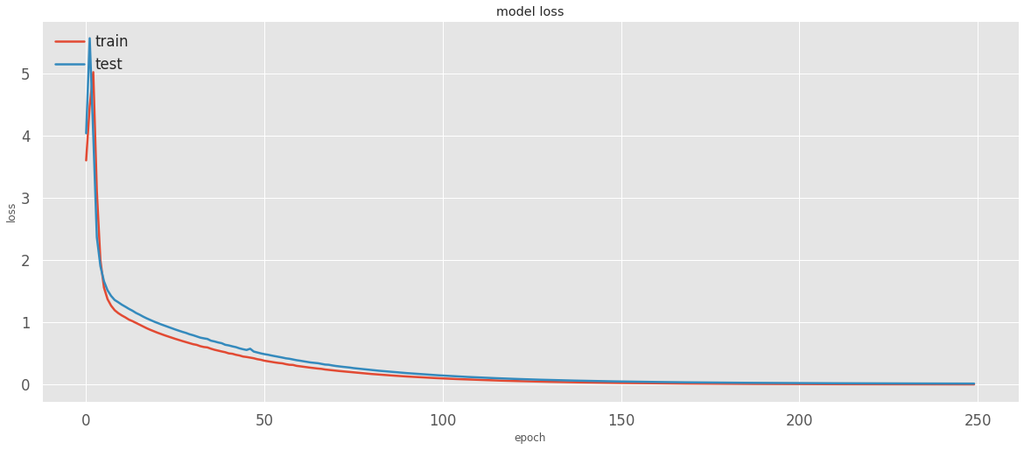

```python
%load_ext tensorboard
%tensorboard --logdir logs
```

%load_ext tensorboard %tensorboard --logdir logs

```
Output hidden; open in https://colab.research.google.com to view.
```

```python
analyzer = cm.analyze_reconstruction(model, X, L, Pc, n_train, p_threshold=p_threshold, policy_threshold=policy_threshold)
highlight("(BCE) Reestimate the entire rating matrix (X) with learned latent factors/embeddings")
reestimated = analyzer(L_test, unreliable_only=False)
highlight("(BCE) Reestimate ONLY the unreliable entries in X with learned latent factors/embeddings")
reestimated = analyzer(L_test, unreliable_only=True)
```

analyzer = cm.analyze_reconstruction(model, X, L, Pc, n_train, p_threshold=p_threshold, policy_threshold=policy_threshold) highlight("(BCE) Reestimate the entire rating matrix (X) with learned latent factors/embeddings") reestimated = analyzer(L_test, unreliable_only=False) highlight("(BCE) Reestimate ONLY the unreliable entries in X with learned latent factors/embeddings") reestimated = analyzer(L_test, unreliable_only=True)

```
================================================================================
(BCE) Reestimate the entire rating matrix (X) with learned latent factors/embeddings
================================================================================
[info] From R to Rh, delta(Frobenius norm)= 53.051820177848285
[info] From T to Th, delta(Frobenius norm)= 25.419679014738062
[info] How different are lh and lh_new? 0.0
[result] Majority vote: F1 score with the original T:  0.18579234972677597
[result] Majority vote: F1 score with re-estimated Th using original p_threshold: 0.18579234972677597
[result] Majority vote: F1 score with re-estimated Th: 0.18579234972677597

[result] Stacking: F1 score with the original T:  0.09859154929577464
[result] Stacking: F1 score with re-estimated Th: 0.18579234972677597

[result] Best settings (complete): lh_maxvote, score: 0.18579234972677597

================================================================================
(BCE) Reestimate ONLY the unreliable entries in X with learned latent factors/embeddings
================================================================================
[info] From R to Rh, delta(Frobenius norm)= 45.78218534396071
[info] From T to Th, delta(Frobenius norm)= 16.581544894914572
[info] How different are lh and lh_new? 0.0
[result] Majority vote: F1 score with the original T:  0.18579234972677597
[result] Majority vote: F1 score with re-estimated Th using original p_threshold: 0.18579234972677597
[result] Majority vote: F1 score with re-estimated Th: 0.18579234972677597

[result] Stacking: F1 score with the original T:  0.09859154929577464
[result] Stacking: F1 score with re-estimated Th: 0.18579234972677597

[result] Best settings (unreliable only): lh_maxvote, score: 0.18579234972677597
```

### 3A. Preparing data for CFNet with the C-squared loss

```python
# import cf_models as cm
assert len(np.unique(Pc.A)) == 4

# Use Cw as weights
Xc, yc, weights, colors = dp.matrix_to_augmented_training_data(X, Cw, Pc) # NOTE: Don't overwrite X (`Xc` is not the same as `X`, which is a rating matrix)
yc = np.column_stack([yc, weights, colors])

# We won't be using sample weights here because they are already being incorporated into the loss
# sample_weights = dp.unravel(Cn, normalize=False) # Cn is a masked and balanced version of C0

# C0 is a raw conficence matrix and should be dense
n_zeros = np.sum(weights == 0)
ratio_zeros = n_zeros/Cw.size
print(f"[info] How many zero weights in C0? {n_zeros}. The ratio of 0s should be small if not zero: {ratio_zeros}")
##########################################

test_size = 0.1

# Make train-test split with sample weights
split_pt = int((1-test_size) * Xc.shape[0])
X_train, X_val, y_train, y_val = (
    Xc[:split_pt],
    Xc[split_pt:],
    yc[:split_pt],
    yc[split_pt:],
)
```

# import cf_models as cm assert len(np.unique(Pc.A)) == 4 # Use Cw as weights Xc, yc, weights, colors = dp.matrix_to_augmented_training_data(X, Cw, Pc) # NOTE: Don't overwrite X (`Xc` is not the same as `X`, which is a rating matrix) yc = np.column_stack([yc, weights, colors]) # We won't be using sample weights here because they are already being incorporated into the loss # sample_weights = dp.unravel(Cn, normalize=False) # Cn is a masked and balanced version of C0 # C0 is a raw conficence matrix and should be dense n_zeros = np.sum(weights == 0) ratio_zeros = n_zeros/Cw.size print(f"[info] How many zero weights in C0? {n_zeros}. The ratio of 0s should be small if not zero: {ratio_zeros}") ########################################## test_size = 0.1 # Make train-test split with sample weights split_pt = int((1-test_size) * Xc.shape[0]) X_train, X_val, y_train, y_val = ( Xc[:split_pt], Xc[split_pt:], yc[:split_pt], yc[split_pt:], )

```
[info] How many zero weights in C0? 505. The ratio of 0s should be small if not zero: 0.020616452337211676
```

### 3B. Create the model

```python
n_factors = 100
epochs = 100
n_users, n_items = X.shape

loss_fn = cm.confidence_weighted_loss
model = cm.get_cfnet_uncompiled(n_users, n_items, n_factors)
model.compile(
        loss=loss_fn, optimizer=keras.optimizers.Adam(lr=0.001)
    )
```

n_factors = 100 epochs = 100 n_users, n_items = X.shape loss_fn = cm.confidence_weighted_loss model = cm.get_cfnet_uncompiled(n_users, n_items, n_factors) model.compile( loss=loss_fn, optimizer=keras.optimizers.Adam(lr=0.001) )

### 3C. Train and evaluate the model

```python
# Use TensorBoard to visualize metrics including loss and accuracy.
tensorboard_callback = tf.keras.callbacks.TensorBoard(log_dir="logs")
history = model.fit(
    x=X_train,
    y=y_train,
    # sample_weight=W_train, # not using sample weight in this case
    batch_size=64,
    epochs=epochs,
    verbose=1,
    validation_data=(X_val, y_val), # test how the model predict unseen ratings
    callbacks=[tensorboard_callback]
)
```

# Use TensorBoard to visualize metrics including loss and accuracy. tensorboard_callback = tf.keras.callbacks.TensorBoard(log_dir="logs") history = model.fit( x=X_train, y=y_train, # sample_weight=W_train, # not using sample weight in this case batch_size=64, epochs=epochs, verbose=1, validation_data=(X_val, y_val), # test how the model predict unseen ratings callbacks=[tensorboard_callback] )

```python
%matplotlib inline
f, ax1 = plt.subplots(nrows=1, ncols=1,figsize=(20,8))

plt.plot(history.history["loss"])
plt.plot(history.history["val_loss"])
plt.title("model loss")
plt.ylabel("loss")
plt.xlabel("epoch")
plt.legend(["train", "test"], loc="upper left")
plt.show()
```

%matplotlib inline f, ax1 = plt.subplots(nrows=1, ncols=1,figsize=(20,8)) plt.plot(history.history["loss"]) plt.plot(history.history["val_loss"]) plt.title("model loss") plt.ylabel("loss") plt.xlabel("epoch") plt.legend(["train", "test"], loc="upper left") plt.show()

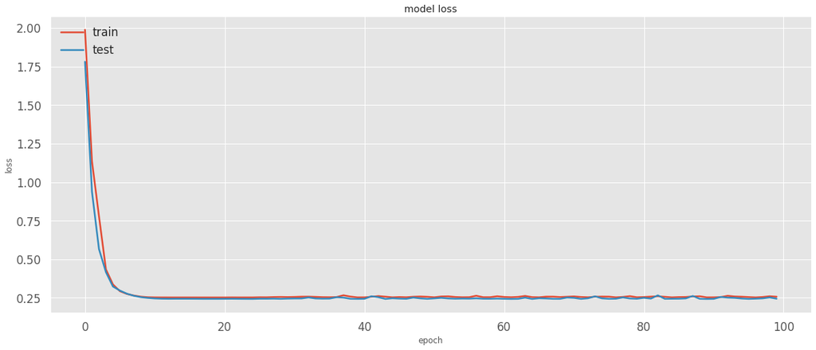

```python
analyzer = cm.analyze_reconstruction(model, X, L, Pc, n_train, p_threshold=p_threshold, policy_threshold=policy_threshold)
highlight("(C-Sqr) Reestimate the entire rating matrix (X) with learned latent factors/embeddings")
reestimated = analyzer(L_test, unreliable_only=False)
highlight("(C-Sqr) Reestimate ONLY the unreliable entries in X with learned latent factors/embeddings")
reestimated = analyzer(L_test, unreliable_only=True)
```

analyzer = cm.analyze_reconstruction(model, X, L, Pc, n_train, p_threshold=p_threshold, policy_threshold=policy_threshold) highlight("(C-Sqr) Reestimate the entire rating matrix (X) with learned latent factors/embeddings") reestimated = analyzer(L_test, unreliable_only=False) highlight("(C-Sqr) Reestimate ONLY the unreliable entries in X with learned latent factors/embeddings") reestimated = analyzer(L_test, unreliable_only=True)

```
================================================================================
(C-Sqr) Reestimate the entire rating matrix (X) with learned latent factors/embeddings
================================================================================
[info] From R to Rh, delta(Frobenius norm)= 38.816793098497804
[info] From T to Th, delta(Frobenius norm)= 21.403534541221376
[info] How different are lh and lh_new? 0.2088
[result] Majority vote: F1 score with the original T:  0.18579234972677597
[result] Majority vote: F1 score with re-estimated Th using original p_threshold: 0.19364161849710984
[result] Majority vote: F1 score with re-estimated Th: 0.19457013574660634

[result] Stacking: F1 score with the original T:  0.09859154929577464
[result] Stacking: F1 score with re-estimated Th: 0.18934911242603553

[result] Best settings (complete): lh2_maxvote_pth_adjusted, score: 0.19457013574660634

================================================================================
(C-Sqr) Reestimate ONLY the unreliable entries in X with learned latent factors/embeddings
================================================================================
[info] From R to Rh, delta(Frobenius norm)= 22.8079703597208
[info] From T to Th, delta(Frobenius norm)= 10.000121918376424
[info] How different are lh and lh_new? 0.0072
[result] Majority vote: F1 score with the original T:  0.18579234972677597
[result] Majority vote: F1 score with re-estimated Th using original p_threshold: 0.18579234972677597
[result] Majority vote: F1 score with re-estimated Th: 0.18750000000000003

[result] Stacking: F1 score with the original T:  0.09859154929577464
[result] Stacking: F1 score with re-estimated Th: 0.1925133689839572

[result] Best settings (unreliable only): lh2_maxvote_pth_adjusted, score: 0.18750000000000003
```

### Experiment #4: CFNet using C-squared loss and sparse confidence matrix

- Use the sparse confidence matrix `Cn` instead of the dense matrix `Cw` in the optimization objective
  - Recall that `Cn` holds confidence scores for TPs and TNs but those associated with FPs and FNs are masked (zeroed out so that they don't enter the optimization objective)

```python
import cf_models as cm
from cf_models import confidence_weighted_loss

n_factors = 100
alpha = 100.0
conf_measure = 'brier'
policy_threshold = 'balanced' # 'fmax'

print(f"[info] input_dir:\n{input_dir}\n")
cm.demo_cfnet_with_csqr_loss(loss_fn=confidence_weighted_loss,
                             ctype='Cn',
                             n_factors=n_factors,
                             alpha=alpha,
                             conf_measure=conf_measure,
                             policy_threshold=policy_threshold, data_dir=os.path.join(input_dir, 'data'))
```

import cf_models as cm from cf_models import confidence_weighted_loss n_factors = 100 alpha = 100.0 conf_measure = 'brier' policy_threshold = 'balanced' # 'fmax' print(f"[info] input_dir:\n{input_dir}\n") cm.demo_cfnet_with_csqr_loss(loss_fn=confidence_weighted_loss, ctype='Cn', n_factors=n_factors, alpha=alpha, conf_measure=conf_measure, policy_threshold=policy_threshold, data_dir=os.path.join(input_dir, 'data'))

```
[info] input_dir:
/content/drive/MyDrive/Colab Notebooks/machine_learning_examples/cf_ensemble

[info] list of base classifiers:
['RF' 'KNNC' 'GNB' 'QDA' 'MLPClassifier']

(estimateProbThresholds) policy: fmax
[info] probability thresholds:
[0.499 0.    0.008 0.    0.007]

> shape(R):(5, 3750) || shape(T): (5, 1250) => shape(X): (5, 5000)
(make_cn) Using WEIGHTED confidence matrix to approximate ratings ...
```

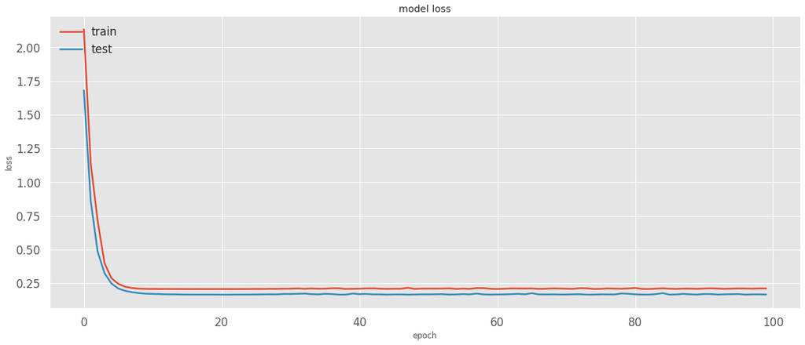

```
================================================================================
(C-Sqr with Cn) Reestimate the entire rating matrix (X) with learned latent factors/embeddings
================================================================================
[info] From R to Rh, delta(Frobenius norm)= 39.16099544127994
[info] From T to Th, delta(Frobenius norm)= 21.753993446623824
[info] How different are lh and lh_new? 0.2336
[result] Majority vote: F1 score with the original T:  0.18579234972677597
[result] Majority vote: F1 score with re-estimated Th using original p_threshold: 0.19364161849710984
[result] Majority vote: F1 score with re-estimated Th: 0.16414686825053992

[result] Stacking: F1 score with the original T:  0.09859154929577464
[result] Stacking: F1 score with re-estimated Th: 0.17610062893081763

[result] Best settings (complete): lh2_maxvote_pth_unadjusted, score: 0.19364161849710984

================================================================================
(C-Sqr with Cn) Reestimate ONLY the unreliable entries in X with learned latent factors/embeddings
================================================================================
[info] From R to Rh, delta(Frobenius norm)= 22.645645639657772
[info] From T to Th, delta(Frobenius norm)= 9.898313781800729
[info] How different are lh and lh_new? 0.0072
[result] Majority vote: F1 score with the original T:  0.18579234972677597
[result] Majority vote: F1 score with re-estimated Th using original p_threshold: 0.18579234972677597
[result] Majority vote: F1 score with re-estimated Th: 0.18750000000000003

[result] Stacking: F1 score with the original T:  0.09859154929577464
[result] Stacking: F1 score with re-estimated Th: 0.1925133689839572

[result] Best settings (unreliable only): lh2_maxvote_pth_adjusted, score: 0.18750000000000003
```

```
<cf_models.CFNet at 0x7f334c0bf9d0>
```

### Experiment #5: CFNet with another version of C-square loss

- Similar to experiment #3 but also use the probability thresholds to account for errors associated with FPs and FNs
- Unlike experiment #4, we'll use `Cw` because we also need to account for FPs and FNs

```python
import cf_models as cm
from cf_models import c_squared_loss

n_factors = 100
alpha = 100.0
conf_measure = 'brier'
policy_threshold = 'balanced' # 'fmax'

cm.demo_cfnet_with_csqr_loss(loss_fn=c_squared_loss,
                             ctype='Cw',
                             n_factors=n_factors,
                             alpha=alpha,
                             conf_measure=conf_measure,
                             policy_threshold=policy_threshold, data_dir=os.path.join(input_dir, 'data'))
```

import cf_models as cm from cf_models import c_squared_loss n_factors = 100 alpha = 100.0 conf_measure = 'brier' policy_threshold = 'balanced' # 'fmax' cm.demo_cfnet_with_csqr_loss(loss_fn=c_squared_loss, ctype='Cw', n_factors=n_factors, alpha=alpha, conf_measure=conf_measure, policy_threshold=policy_threshold, data_dir=os.path.join(input_dir, 'data'))

```
[info] list of base classifiers:
['RF' 'KNNC' 'GNB' 'QDA' 'MLPClassifier']

(estimateProbThresholds) policy: fmax
[info] probability thresholds:
[0.499 0.    0.008 0.    0.007]

> shape(R):(5, 3750) || shape(T): (5, 1250) => shape(X): (5, 5000)
(make_cn) Using WEIGHTED confidence matrix to approximate ratings ...
```

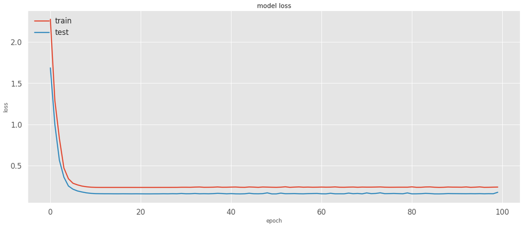

```
================================================================================
(C-Sqr with Cw) Reestimate the entire rating matrix (X) with learned latent factors/embeddings
================================================================================
[info] From R to Rh, delta(Frobenius norm)= 37.82624812811406
[info] From T to Th, delta(Frobenius norm)= 20.908288958328175
[info] How different are lh and lh_new? 0.192
[result] Majority vote: F1 score with the original T:  0.18579234972677597
[result] Majority vote: F1 score with re-estimated Th using original p_threshold: 0.19392185238784368
[result] Majority vote: F1 score with re-estimated Th: 0.20537897310513448

[result] Stacking: F1 score with the original T:  0.09859154929577464
[result] Stacking: F1 score with re-estimated Th: 0.18181818181818182

[result] Best settings (complete): lh2_maxvote_pth_adjusted, score: 0.20537897310513448

================================================================================
(C-Sqr with Cw) Reestimate ONLY the unreliable entries in X with learned latent factors/embeddings
================================================================================
[info] From R to Rh, delta(Frobenius norm)= 23.580730236422873
[info] From T to Th, delta(Frobenius norm)= 10.321363800157425
[info] How different are lh and lh_new? 0.0072
[result] Majority vote: F1 score with the original T:  0.18579234972677597
[result] Majority vote: F1 score with re-estimated Th using original p_threshold: 0.18579234972677597
[result] Majority vote: F1 score with re-estimated Th: 0.18750000000000003

[result] Stacking: F1 score with the original T:  0.09859154929577464
[result] Stacking: F1 score with re-estimated Th: 0.1925133689839572

[result] Best settings (unreliable only): lh2_maxvote_pth_adjusted, score: 0.18750000000000003
```

```
<cf_models.CFNet at 0x7f334bbaf410>
```

### Useful utility functions

- data_pipeline.iterporate()

```python
# import data_pipeline as dp


# Interporate (NOT in the sense of its use in regression):
# useful for matrix reconstruction using latent factors
###############################
X = np.random.choice(range(1, 6), (3, 10))
T = np.repeat(99, 3*10).reshape(3, 10)
M = np.where(X%2==0, 1, 0)
print(f"X:\n{X}\n")
print(f"T:\n{T}\n")
print(f"M:\n{M}\n")

Xp = cm.interpolate(X, T, Pc=M)
print(f"Xp:\n{Xp}\n")

# Training data preparation
################################
D = np.random.choice(range(10), (5, 5))
print(D); print()
scores = dp.unravel(D, verify=1)
assert len(scores) == D.size
print(scores)
```

# import data_pipeline as dp # Interporate (NOT in the sense of its use in regression): # useful for matrix reconstruction using latent factors ############################### X = np.random.choice(range(1, 6), (3, 10)) T = np.repeat(99, 3*10).reshape(3, 10) M = np.where(X%2==0, 1, 0) print(f"X:\n{X}\n") print(f"T:\n{T}\n") print(f"M:\n{M}\n") Xp = cm.interpolate(X, T, Pc=M) print(f"Xp:\n{Xp}\n") # Training data preparation ################################ D = np.random.choice(range(10), (5, 5)) print(D); print() scores = dp.unravel(D, verify=1) assert len(scores) == D.size print(scores)

```
X:
[[1 1 4 2 1 4 4 5 1 2]
 [5 4 3 3 5 3 5 4 4 1]
 [4 3 2 2 3 3 5 2 4 5]]

T:
[[99 99 99 99 99 99 99 99 99 99]
 [99 99 99 99 99 99 99 99 99 99]
 [99 99 99 99 99 99 99 99 99 99]]

M:
[[0 0 1 1 0 1 1 0 0 1]
 [0 1 0 0 0 0 0 1 1 0]
 [1 0 1 1 0 0 0 1 1 0]]

Xp:
[[99. 99.  4.  2. 99.  4.  4. 99. 99.  2.]
 [99.  4. 99. 99. 99. 99. 99.  4.  4. 99.]
 [ 4. 99.  2.  2. 99. 99. 99.  2.  4. 99.]]

[[9 3 0 1 3]
 [3 5 0 5 6]
 [0 5 9 7 4]
 [0 3 9 4 7]
 [0 8 2 6 9]]

[9 3 0 1 3 3 5 0 5 6 0 5 9 7 4 0 3 9 4 7 0 8 2 6 9]
```

- From user-item pairs (representing implicit feedbacks), construct corresponding a sparse (rating) matrices

```python
from scipy import sparse

# Simulate users rating on items
df_ui = pd.DataFrame([['a', 'abc'],['b', 'def'],['c', 'ghi'],
                      ['d', 'abc'],['a', 'ghi'],['e', 'fg'],
                      ['f', 'f76'],['b', 'f76']],
                 columns = ['user','item'])
display(df_ui)
UI = df_ui.values
print()

# I: row coordiante, J: column coordinate
users, I = np.unique(UI[:,0], return_inverse=True)
items, J = np.unique(UI[:,1], return_inverse=True)
positives = np.ones(len(UI), int) # points with a positive polarity (where users gave implicit feedback on items)
Po = sparse.coo_matrix((positives, (I, J)))

print(Po); print()
print(Po.A)
assert np.all(Po.A[(I, J)] == 1), "All (I, J) positions should be positive (1)"
```

from scipy import sparse # Simulate users rating on items df_ui = pd.DataFrame([['a', 'abc'],['b', 'def'],['c', 'ghi'], ['d', 'abc'],['a', 'ghi'],['e', 'fg'], ['f', 'f76'],['b', 'f76']], columns = ['user','item']) display(df_ui) UI = df_ui.values print() # I: row coordiante, J: column coordinate users, I = np.unique(UI[:,0], return_inverse=True) items, J = np.unique(UI[:,1], return_inverse=True) positives = np.ones(len(UI), int) # points with a positive polarity (where users gave implicit feedback on items) Po = sparse.coo_matrix((positives, (I, J))) print(Po); print() print(Po.A) assert np.all(Po.A[(I, J)] == 1), "All (I, J) positions should be positive (1)"

|  | user | item |
| --- | --- | --- |
| 0 | a | abc |
| 1 | b | def |
| 2 | c | ghi |
| 3 | d | abc |
| 4 | a | ghi |
| 5 | e | fg |
| 6 | f | f76 |
| 7 | b | f76 |

```
  (0, 0)	1
  (1, 1)	1
  (2, 4)	1
  (3, 0)	1
  (0, 4)	1
  (4, 3)	1
  (5, 2)	1
  (1, 2)	1

[[1 0 0 0 1]
 [0 1 1 0 0]
 [0 0 0 0 1]
 [1 0 0 0 0]
 [0 0 0 1 0]
 [0 0 1 0 0]]
```